# EEG Feature Analysis

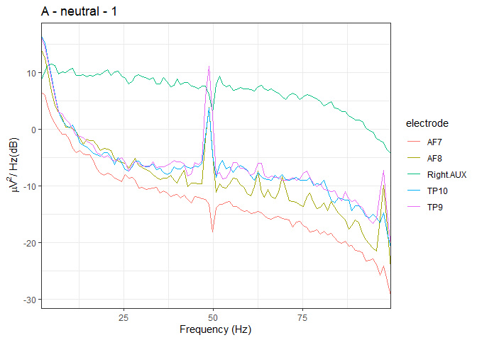

```r
show_psd(a_neutral_1_obj, "A - neutral - 1")
```

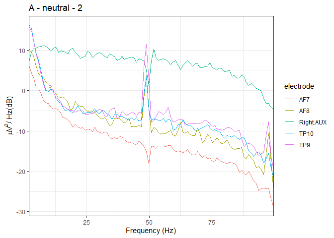

```r
show_psd(a_neutral_2_obj, "A - neutral - 2")
```

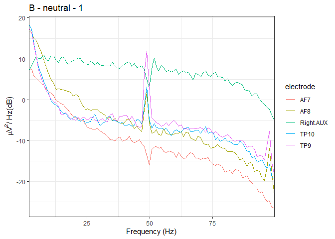

```r
show_psd(b_neutral_1_obj, "B - neutral - 1")
```

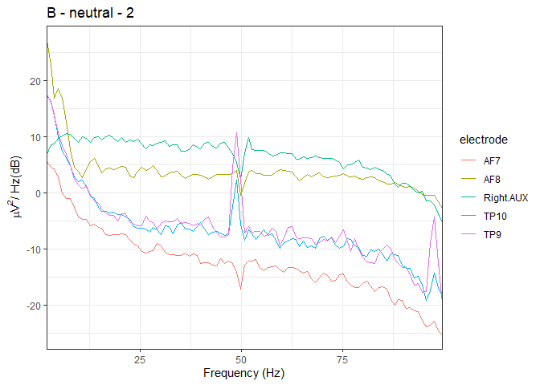

```r
show_psd(b_neutral_2_obj, "B - neutral - 2")
```

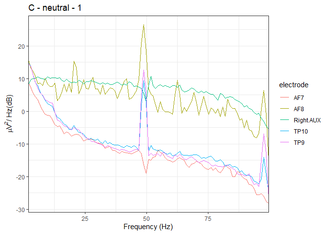

```r
show_psd(c_neutral_1_obj, "C - neutral - 1")
```

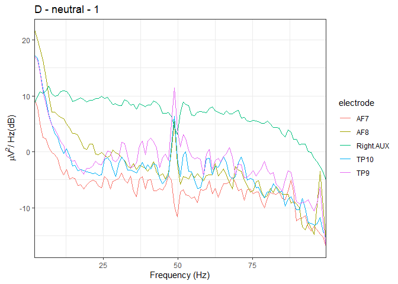

```r
show_psd(d_neutral_1_obj, "D - neutral - 1")
```

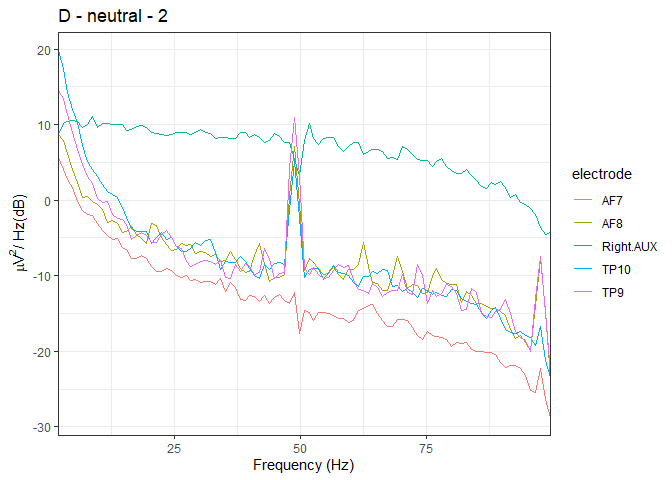

```r
show_psd(d_neutral_2_obj, "D - neutral - 2")
```

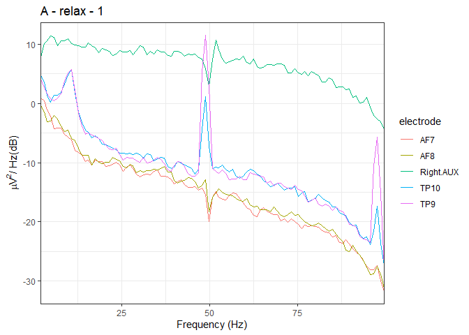

```r
show_psd(a_relaxed_1_obj, "A - relax - 1")
```

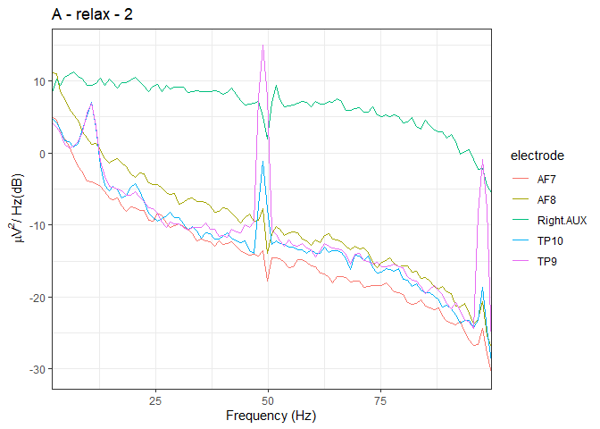

```r
show_psd(a_relaxed_2_obj, "A - relax - 2")
```

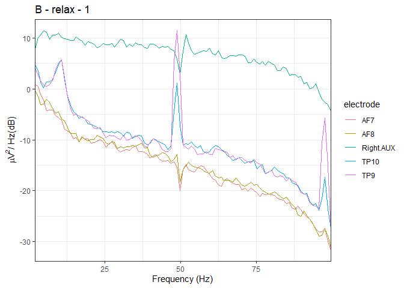

```r
show_psd(a_relaxed_1_obj, "B - relax - 1")
```

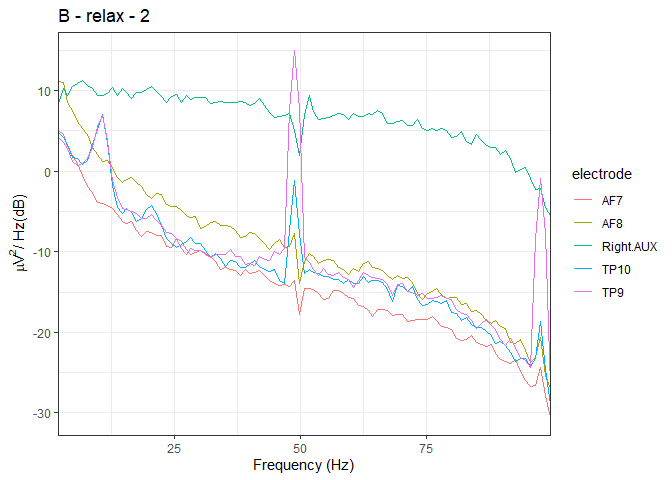

```r
show_psd(a_relaxed_2_obj, "B - relax - 2")
```

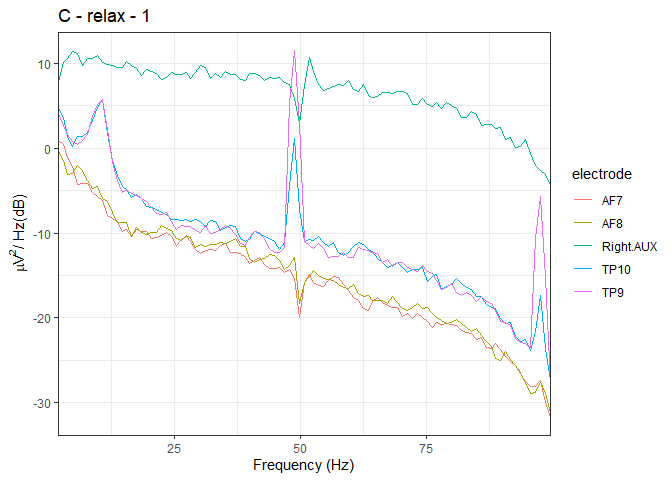

```r
show_psd(a_relaxed_1_obj, "C - relax - 1")
```

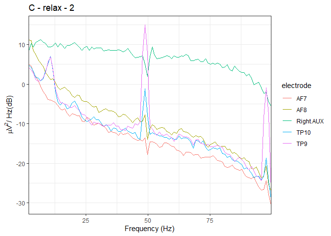

```r
show_psd(a_relaxed_2_obj, "C - relax - 2")
```

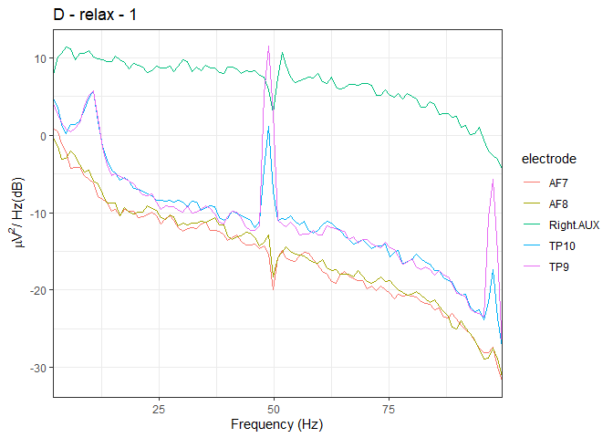

```r
show_psd(a_relaxed_1_obj, "D - relax - 1")
```

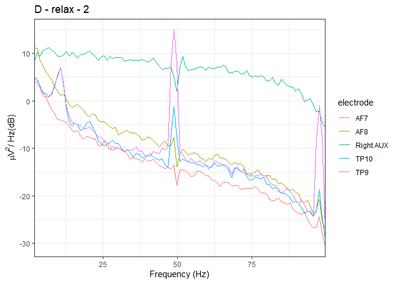

```r
show_psd(a_relaxed_2_obj, "D - relax - 2")
```

We noticed that Right.AUX recordings doesn’t help in pattern recognition (values always oscillates around similar power for a given frequencies, despite the mental state). That’s why for averaged frequency-time analysis we drop this channel.

Below we clearly see, that during concentration brain waves have higher amplitudes. The lowest brain activity is during relaxation.

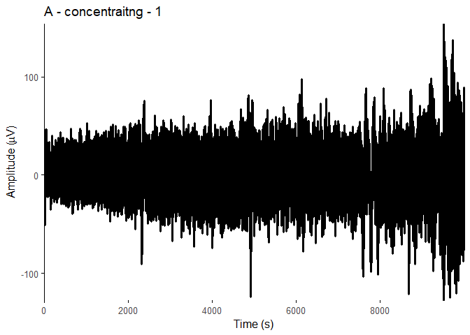

```r
show_timecourse <- function(eeg_obj, title) {
  return (plot_timecourse(eeg_obj, electrode = c("AF7", "AF8", "TP10", "TP10")) + ggtitle(title))
}

show_timecourse(a_concentrating_1_obj, "A - concentraitng - 1")
```

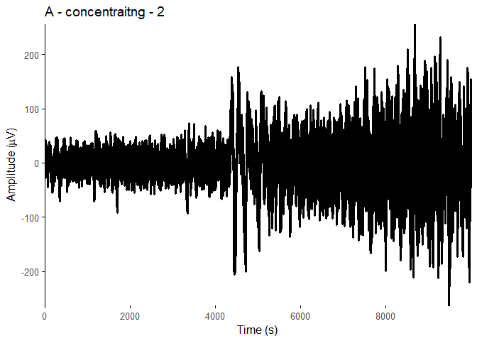

```r
show_timecourse(a_concentrating_2_obj, "A - concentraitng - 2")
```

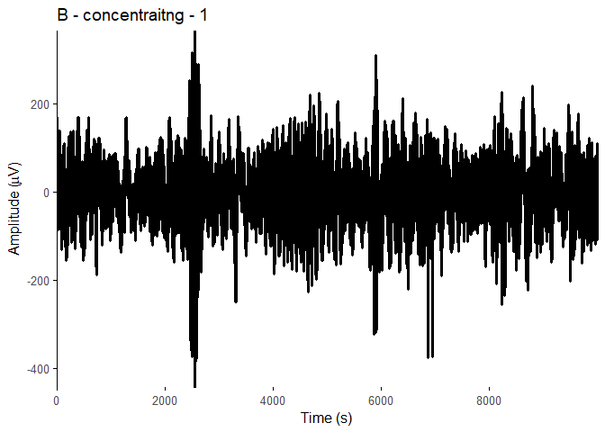

```r
show_timecourse(b_concentrating_1_obj, "B - concentraitng - 1")
```

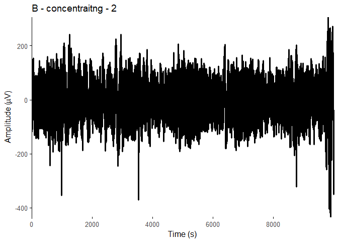

```r
show_timecourse(b_concentrating_2_obj, "B - concentraitng - 2")
```

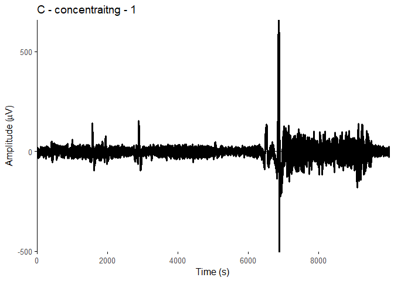

```r
show_timecourse(c_concentrating_1_obj, "C - concentraitng - 1")
```

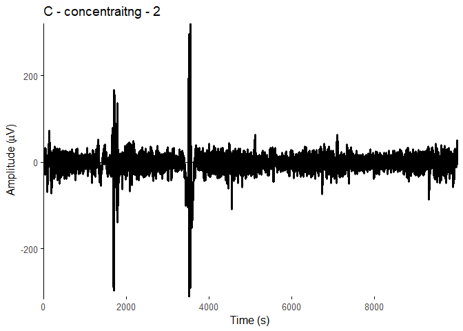

```r
show_timecourse(c_concentrating_2_obj, "C - concentraitng - 2")
```

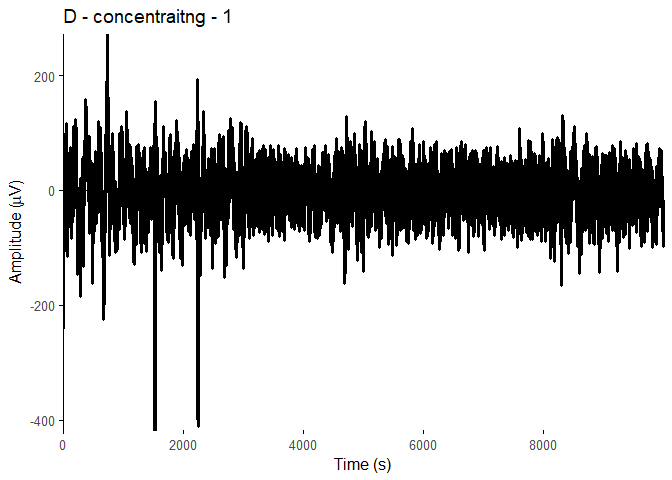

```r
show_timecourse(d_concentrating_1_obj, "D - concentraitng - 1")
```

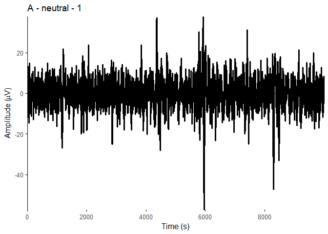

```r
show_timecourse(a_neutral_1_obj, "A - neutral - 1")
```

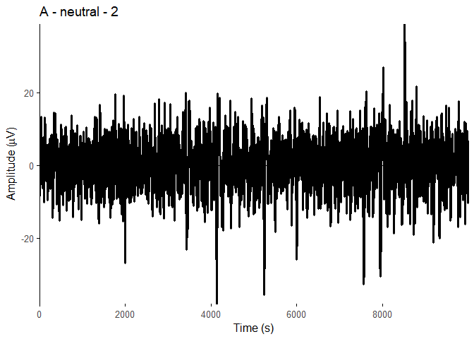

```r
show_timecourse(a_neutral_2_obj, "A - neutral - 2")
```

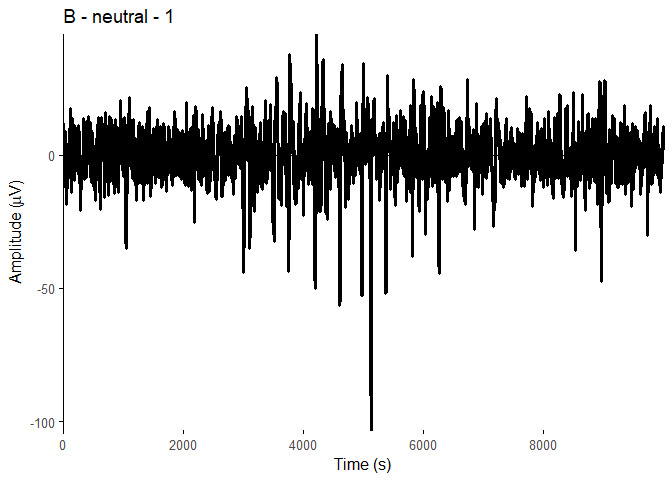

```r
show_timecourse(b_neutral_1_obj, "B - neutral - 1")
```

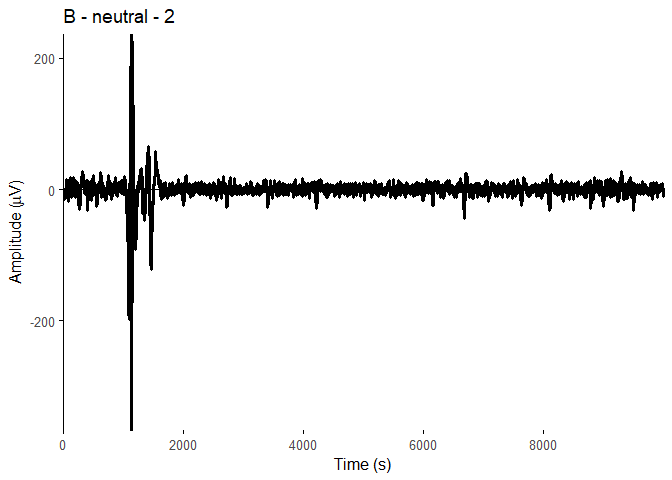

```r
show_timecourse(b_neutral_2_obj, "B - neutral - 2")
```

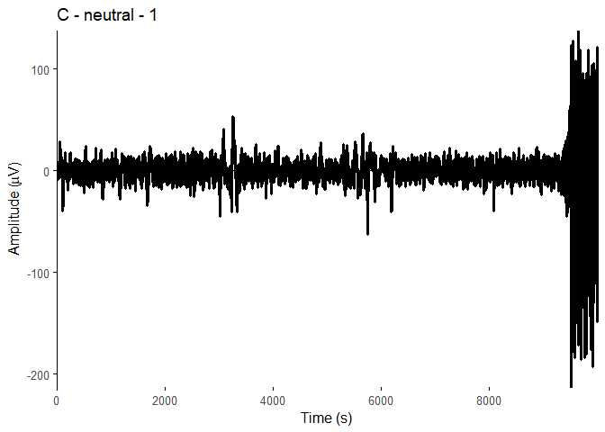

```r
show_timecourse(c_neutral_1_obj, "C - neutral - 1")
```

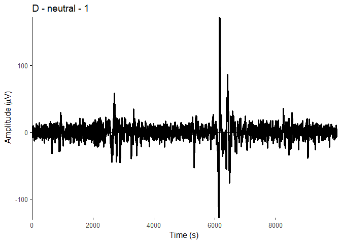

```r
show_timecourse(d_neutral_1_obj, "D - neutral - 1")
```

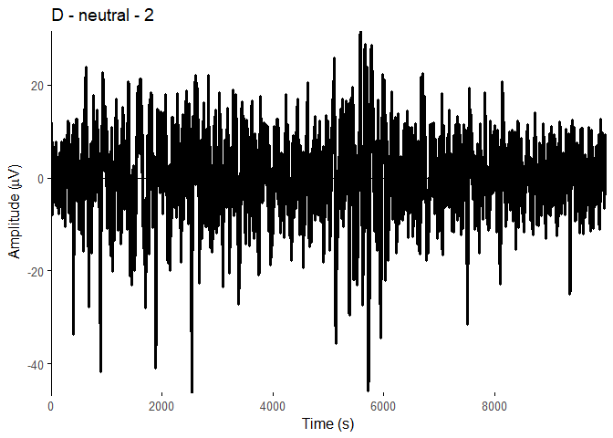

```r
show_timecourse(d_neutral_2_obj, "D - neutral - 2")
```

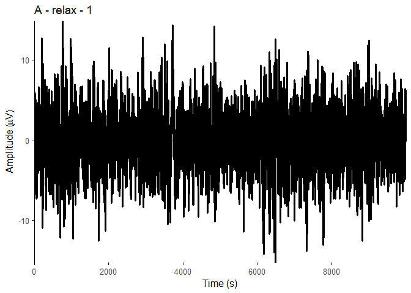

```r
show_timecourse(a_relaxed_1_obj, "A - relax - 1")
```

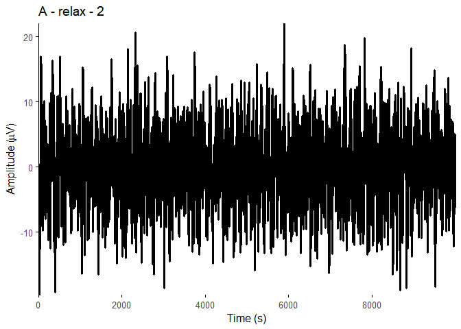

```r
show_timecourse(a_relaxed_2_obj, "A - relax - 2")
```

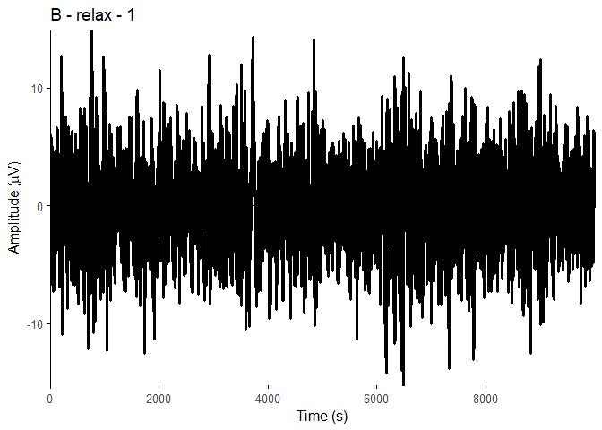

```r
show_timecourse(a_relaxed_1_obj, "B - relax - 1")
```

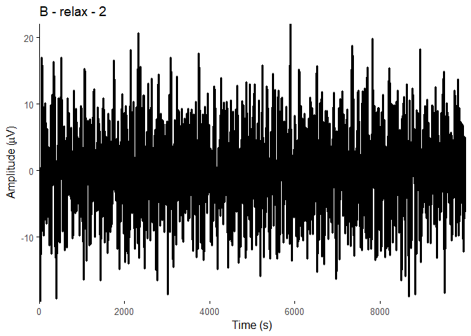

```r
show_timecourse(a_relaxed_2_obj, "B - relax - 2")
```

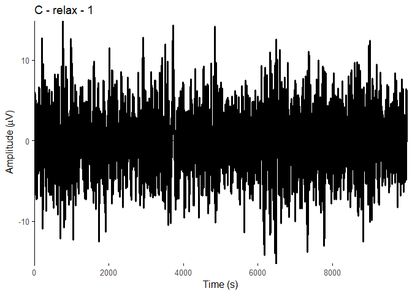

```r
show_timecourse(a_relaxed_1_obj, "C - relax - 1")
```

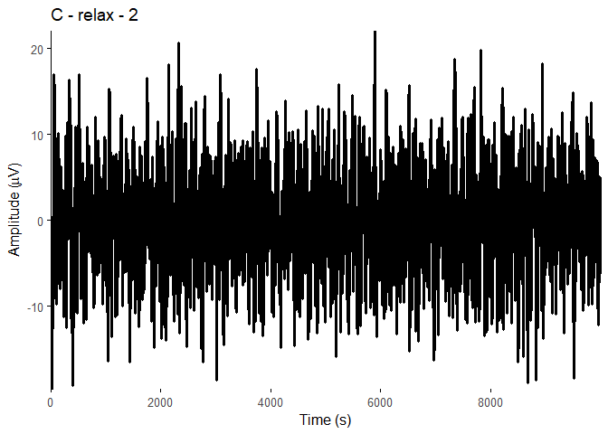

```r
show_timecourse(a_relaxed_2_obj, "C - relax - 2")
```

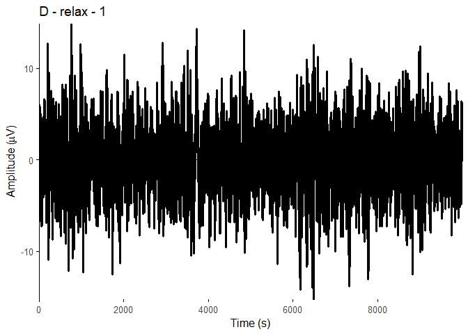

```r
show_timecourse(a_relaxed_1_obj, "D - relax - 1")
```

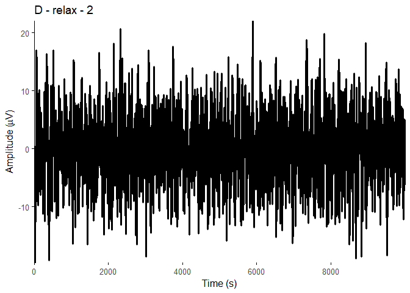

```r
show_timecourse(a_relaxed_2_obj, "D - relax - 2")
```

### Feature extraction

In order to better identify patterns or characteristics in the EEG data that are associated with specific mental states, we apply difference between EEG data during different mental states and a baseline (averaged neutral) state to extract features that represent the differences in brain activity across these states.

```r
a_base = (a_neutral_1 + a_neutral_2) / 2
a_concentrating_1_obj <- wrap(a_concentrating_1 - a_base)
a_concentrating_2_obj <- wrap(a_concentrating_2 - a_base)
a_neutral_1_obj <- wrap(a_neutral_1 - a_base)
a_neutral_2_obj <- wrap(a_neutral_2 - a_base)
a_relaxed_1_obj <- wrap(a_relaxed_1 - a_base)
a_relaxed_2_obj <- wrap(a_relaxed_2 - a_base)

b_base = (b_neutral_1 + b_neutral_2) / 2
b_concentrating_1_obj <- wrap(b_concentrating_1 - b_base)
b_concentrating_2_obj <- wrap(b_concentrating_2 - b_base)
b_neutral_1_obj <- wrap(b_neutral_1 - b_base)
b_neutral_2_obj <- wrap(b_neutral_2 - b_base)
b_relaxed_1_obj <- wrap(b_relaxed_1 - b_base)
b_relaxed_2_obj <- wrap(b_relaxed_2 - b_base)

c_base = c_neutral_1
c_concentrating_1_obj <- wrap(c_concentrating_1 - c_base)
c_concentrating_2_obj <- wrap(c_concentrating_2 - c_base)
c_neutral_1_obj <- wrap(c_neutral_1 - c_base)
#c_neutral_2_obj <- wrap(c_neutral_2)
c_relaxed_1_obj <- wrap(c_relaxed_1 - c_base)
c_relaxed_2_obj <- wrap(c_relaxed_2 - c_base)

d_base = (d_neutral_1 + d_neutral_2) / 2
d_concentrating_1_obj <- wrap(d_concentrating_1 - d_base)
d_neutral_1_obj <- wrap(d_neutral_1 - d_base)
d_neutral_2_obj <- wrap(d_neutral_2 - d_base)
d_relaxed_1_obj <- wrap(d_relaxed_1 - d_base)
d_relaxed_2_obj <- wrap(d_relaxed_2 - d_base)
```

After applying the baseline results are more distinct for different states. For concentration power is distributed evenly, whereas for relaxation, the plot is left-skewed.

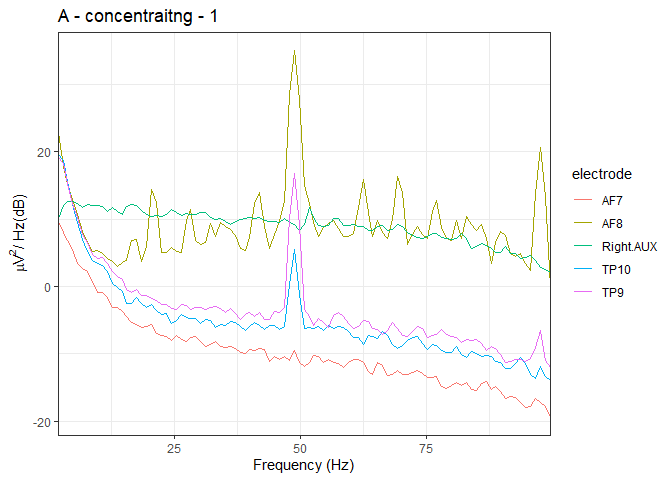

```r
show_psd <- function(eeg_obj, title) {
  return (plot_psd(eeg_obj, freq_range = c(1, 100), ) + ggtitle(title))
}

show_psd(a_concentrating_1_obj, "A - concentraitng - 1")
```

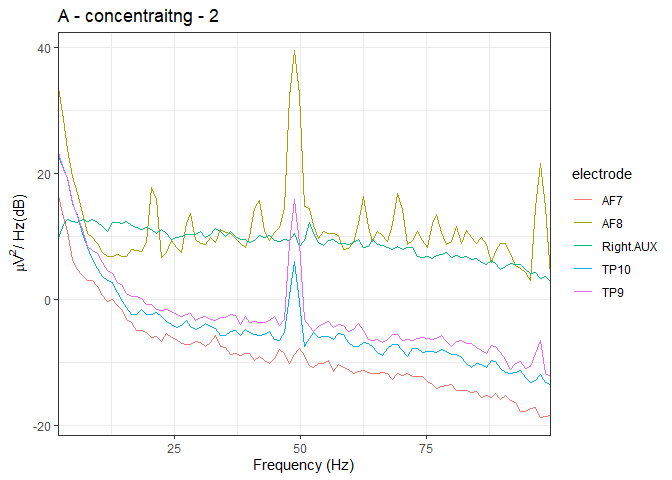

```r
show_psd(a_concentrating_2_obj, "A - concentraitng - 2")
```

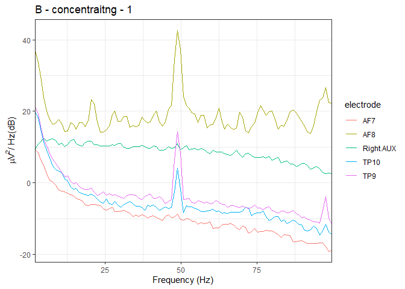

```r
show_psd(b_concentrating_1_obj, "B - concentraitng - 1")
```

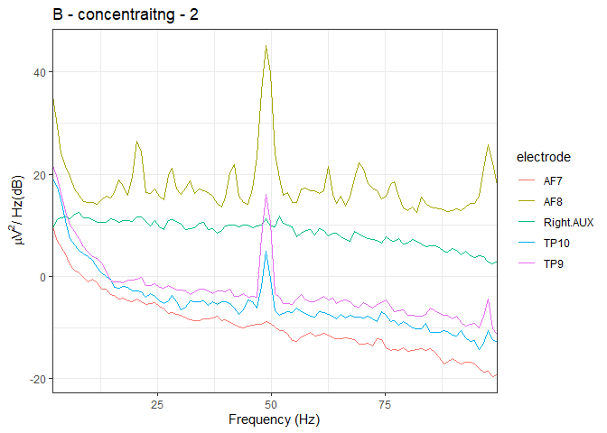

```r
show_psd(b_concentrating_2_obj, "B - concentraitng - 2")
```

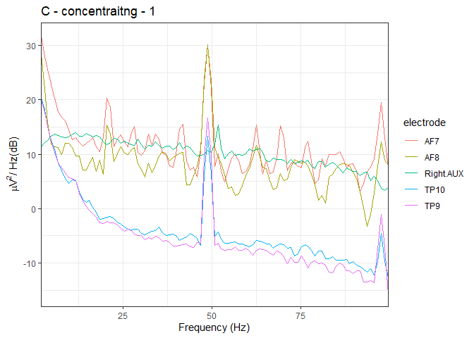

```r
show_psd(c_concentrating_1_obj, "C - concentraitng - 1")
```

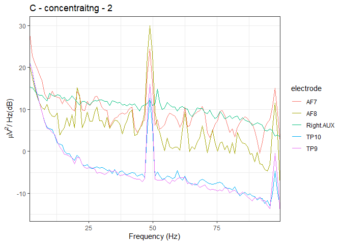

```r
show_psd(c_concentrating_2_obj, "C - concentraitng - 2")
```

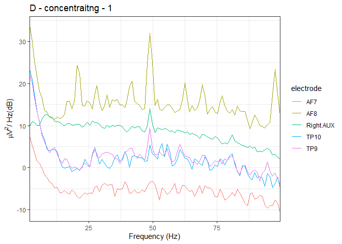

```r
show_psd(d_concentrating_1_obj, "D - concentraitng - 1")
```